# Polynomial Pratice

Jinwoo Chung

## Table of Contents

1. Setup (Data is from gapminder)
2. Separate Train and Test Data
3. Plot (locate Significant Variables)
4. Linear Regression, Quadratic Regression, Cubic Regression, Polynomial Regression
5. 3-fold Cross Validation (Use only 1350 of Train Data)
6. Compare Linear Regression and other Polynomial Regression
7. **Conditional** There are some problems with Fourth Power Regression, locate and elaborate

### Setup

```r
library(pacman)
pacman::p_load(gapminder,dplyr)
glimpse(gapminder)
```

```
## Observations: 1,704
## Variables: 6
## $ country   <fct> Afghanistan, Afghanistan, Afghanistan, Afghanistan, ...
## $ continent <fct> Asia, Asia, Asia, Asia, Asia, Asia, Asia, Asia, Asia...
## $ year      <int> 1952, 1957, 1962, 1967, 1972, 1977, 1982, 1987, 1992...
## $ lifeExp   <dbl> 28.801, 30.332, 31.997, 34.020, 36.088, 38.438, 39.8...
## $ pop       <int> 8425333, 9240934, 10267083, 11537966, 13079460, 1488...
## $ gdpPercap <dbl> 779.4453, 820.8530, 853.1007, 836.1971, 739.9811, 78...
```

### Separate Train and Test Data

```r
set.seed(123)
index.train <- sample(1:nrow(gapminder), round(nrow(gapminder) * 0.8))
train <- gapminder[index.train, ]
test <- gapminder[-index.train, ]
train
```

```
## # A tibble: 1,363 x 6
##    country           continent  year lifeExp       pop gdpPercap
##    <fct>             <fct>     <int>   <dbl>     <int>     <dbl>
##  1 Equatorial Guinea Africa     2002    49.3    495627     7703.
##  2 Serbia            Europe     2002    73.2  10111559     7236.
##  3 India             Asia       1952    37.4 372000000      547.
##  4 Taiwan            Asia       1962    65.2  11918938     1823.
##  5 United Kingdom    Europe     1962    70.8  53292000    12477.
##  6 Austria           Europe     1977    72.2   7568430    19749.
##  7 Liberia           Africa     1992    40.8   1912974      637.
##  8 Tanzania          Africa     1962    44.2  10863958      722.
##  9 Malawi            Africa     2007    48.3  13327079      759.
## 10 Italy             Europe     1977    73.5  56059245    14256.
## # ... with 1,353 more rows
```

### Plot (locate Significant Variables)

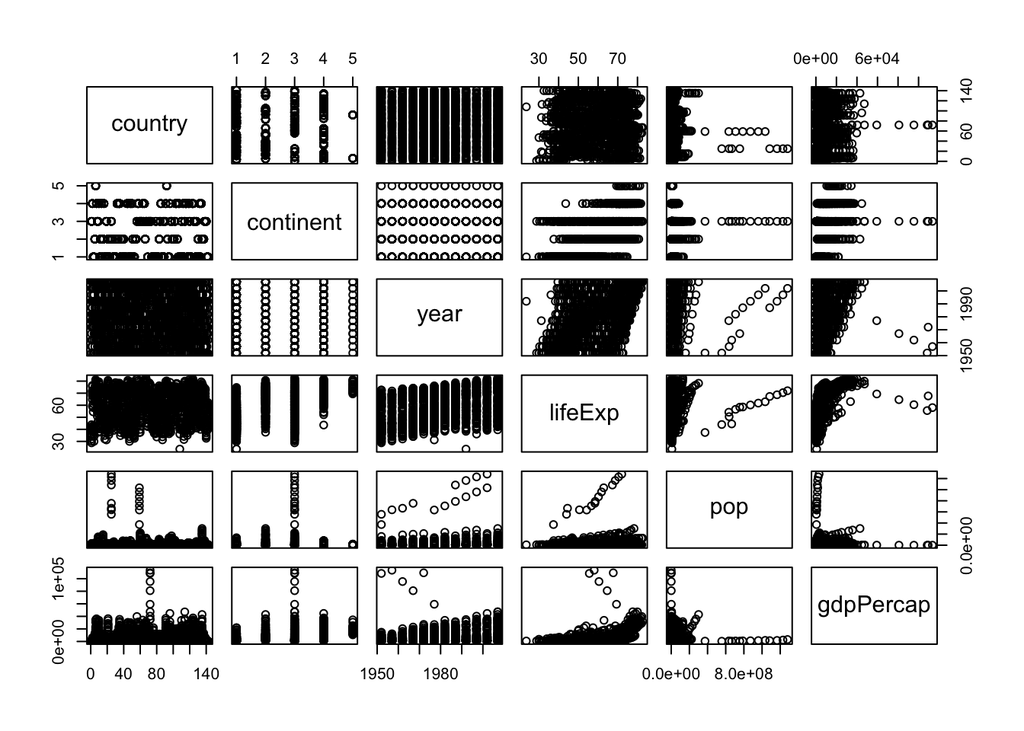

```r
pairs(train)
```

Removing countries and continents

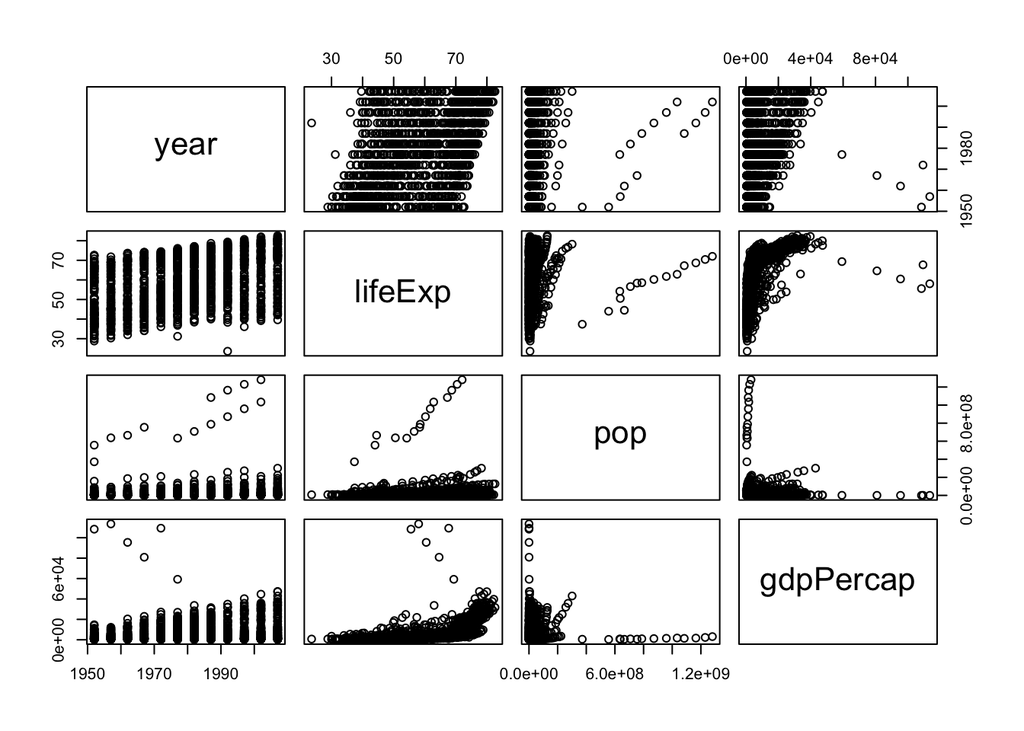

```r
pairs(~ year + lifeExp + pop + gdpPercap, data=train)
```

**Choosing lifeExp as dependent var**

### Linear Regression, Quadratic Regression, Cubic Regression, Polynomial Regression

1. Linear Regression

```r
lm.lin.gapminder <- lm(lifeExp ~ year + pop + gdpPercap, data = train)
summary(lm.lin.gapminder)
```

```
##
## Call:
## lm(formula = lifeExp ~ year + pop + gdpPercap, data = train)
##
## Residuals:
##     Min      1Q  Median      3Q     Max
## -63.908  -6.802   1.089   7.794  19.993
##
## Coefficients:
##               Estimate Std. Error t value Pr(>|t|)
## (Intercept) -4.268e+02  3.118e+01 -13.688   <2e-16 ***
## year         2.432e-01  1.578e-02  15.414   <2e-16 ***
## pop          7.082e-09  2.780e-09   2.548    0.011 *
## gdpPercap    6.421e-04  2.686e-05  23.909   <2e-16 ***
## ---
## Signif. codes:  0 '***' 0.001 '**' 0.01 '*' 0.05 '.' 0.1 ' ' 1
##
## Residual standard error: 9.83 on 1359 degrees of freedom
## Multiple R-squared:  0.4287, Adjusted R-squared:  0.4275
## F-statistic:   340 on 3 and 1359 DF,  p-value: < 2.2e-16
```

R-squared values are pretty low and pop p-value seems pretty low as well.

2. Quadratic Regression

```r
lm.quad.gapminder <- lm(lifeExp ~ year + I(year^2) +
                          pop + I(pop^2) +
                          gdpPercap + I(gdpPercap^2), data = train)
summary(lm.quad.gapminder)
```

```
##
## Call:
## lm(formula = lifeExp ~ year + I(year^2) + pop + I(pop^2) + gdpPercap +
##     I(gdpPercap^2), data = train)
##
## Residuals:
##      Min       1Q   Median       3Q      Max
## -31.0990  -6.0682   0.1186   6.6805  21.6872
##
## Coefficients:
##                  Estimate Std. Error t value Pr(>|t|)
## (Intercept)    -1.152e+04  3.316e+03  -3.472 0.000532 ***
## year            1.151e+01  3.351e+00   3.435 0.000611 ***
## I(year^2)      -2.862e-03  8.463e-04  -3.382 0.000741 ***
## pop             1.148e-08  6.704e-09   1.713 0.086916 .
## I(pop^2)       -3.155e-18  6.792e-18  -0.464 0.642406
## gdpPercap       1.399e-03  4.054e-05  34.523  < 2e-16 ***
## I(gdpPercap^2) -1.310e-08  5.781e-10 -22.664  < 2e-16 ***
## ---
## Signif. codes:  0 '***' 0.001 '**' 0.01 '*' 0.05 '.' 0.1 ' ' 1
##
## Residual standard error: 8.319 on 1356 degrees of freedom
## Multiple R-squared:  0.5918, Adjusted R-squared:   0.59
## F-statistic: 327.6 on 6 and 1356 DF,  p-value: < 2.2e-16
```

R-squared values went up, but pop is starting to lose its value as an independent variable. **pop variable will be omitted**

3. Cubic Regression

```r
lm.cub.gapminder <- lm(lifeExp ~ year + I(year^2) + I(year^3) +
                          gdpPercap + I(gdpPercap^2) + I(gdpPercap^3), data = train)
summary(lm.cub.gapminder)
```

```
##
## Call:
## lm(formula = lifeExp ~ year + I(year^2) + I(year^3) + gdpPercap +
##     I(gdpPercap^2) + I(gdpPercap^3), data = train)
##
## Residuals:
##      Min       1Q   Median       3Q      Max
## -29.3390  -4.4169  -0.2596   5.4183  30.7382
##
## Coefficients:
##                  Estimate Std. Error t value Pr(>|t|)
## (Intercept)     4.087e+05  4.062e+05   1.006    0.314
## year           -6.220e+02  6.156e+02  -1.010    0.313
## I(year^2)       3.154e-01  3.110e-01   1.014    0.311
## I(year^3)      -5.330e-05  5.237e-05  -1.018    0.309
## gdpPercap       2.590e-03  7.635e-05  33.920   <2e-16 ***
## I(gdpPercap^2) -6.768e-08  3.110e-09 -21.760   <2e-16 ***
## I(gdpPercap^3)  4.188e-13  2.351e-14  17.811   <2e-16 ***
## ---
## Signif. codes:  0 '***' 0.001 '**' 0.01 '*' 0.05 '.' 0.1 ' ' 1
##
## Residual standard error: 7.523 on 1356 degrees of freedom
## Multiple R-squared:  0.6662, Adjusted R-squared:  0.6647
## F-statistic:   451 on 6 and 1356 DF,  p-value: < 2.2e-16
```

4. Fourth Power Regression

```r
lm.four.gapminder <- lm(lifeExp ~ year + I(year^2) + I(year^3) + I(year^4) +
                          gdpPercap + I(gdpPercap^2) + I(gdpPercap^3) + I(gdpPercap^4), data = train)
summary(lm.four.gapminder)
```

```
##
## Call:
## lm(formula = lifeExp ~ year + I(year^2) + I(year^3) + I(year^4) +
##     gdpPercap + I(gdpPercap^2) + I(gdpPercap^3) + I(gdpPercap^4),
##     data = train)
##
## Residuals:
##      Min       1Q   Median       3Q      Max
## -28.8854  -3.9702   0.1937   4.8387  17.0710
##
## Coefficients: (1 not defined because of singularities)
##                  Estimate Std. Error t value Pr(>|t|)
## (Intercept)     6.979e+05  3.879e+05   1.799   0.0722 .
## year           -1.059e+03  5.879e+02  -1.801   0.0718 .
## I(year^2)       5.357e-01  2.970e-01   1.803   0.0715 .
## I(year^3)      -9.028e-05  5.001e-05  -1.805   0.0713 .
## I(year^4)              NA         NA      NA       NA
## gdpPercap       3.536e-03  1.086e-04  32.565   <2e-16 ***
## I(gdpPercap^2) -1.395e-07  6.796e-09 -20.521   <2e-16 ***
## I(gdpPercap^3)  1.947e-12  1.321e-13  14.738   <2e-16 ***
## I(gdpPercap^4) -8.714e-18  7.424e-19 -11.738   <2e-16 ***
## ---
## Signif. codes:  0 '***' 0.001 '**' 0.01 '*' 0.05 '.' 0.1 ' ' 1
##
## Residual standard error: 7.17 on 1355 degrees of freedom
## Multiple R-squared:  0.697,  Adjusted R-squared:  0.6954
## F-statistic: 445.2 on 7 and 1355 DF,  p-value: < 2.2e-16
```

Fourth Power on year has NA value. (this is the problem that **Condition** has stated in the Table of Contents). This problem arises due to multicolinearity.

## 3-fold Cross Validation (Use only 1350 of Train Data)

Splitting Data for 3-fold CV (no repeat)

```r
train.random <- sample(train)[1:1350,]
train.D1 <- train.random[1:450,]
train.D2 <- train.random[451:900,]
train.D3 <- train.random[901:1350,]
```

Linear Regression (using only year and gdpPercap as independent variable)

```r
# Excluding D1
lm.linear.cv1 <- lm(lifeExp ~ year + gdpPercap,
                    data = rbind(train.D2, train.D3))
# MSE
mse.linear.cv1 <- mean((predict(lm.linear.cv1, newdata=train.D1) - train.D1$lifeExp)^2)

# Excluding D2
lm.linear.cv2 <- lm(lifeExp ~ year + gdpPercap,
                    data = rbind(train.D1, train.D3))
# MSE
mse.linear.cv2 <- mean((predict(lm.linear.cv1, newdata=train.D2) - train.D2$lifeExp)^2)

# Excluding D3
lm.linear.cv3 <- lm(lifeExp ~ year + gdpPercap,
                    data = rbind(train.D1, train.D2))
# MSE
mse.linear.cv3 <- mean((predict(lm.linear.cv1, newdata=train.D3) - train.D3$lifeExp)^2)

# Average of MSE
(mse.linear.cv1 + mse.linear.cv2 + mse.linear.cv3) / 3
```

```
## [1] 97.46819
```

Quadratic Regression (using only year and gdpPercap as independent variable)

```r
# Excluding D1
lm.quad.cv1 <- lm(lifeExp ~ year + I(year^2) + gdpPercap + I(gdpPercap^2),
                    data = rbind(train.D2, train.D3))
# MSE
mse.quad.cv1 <- mean((predict(lm.quad.cv1, newdata=train.D1) - train.D1$lifeExp)^2)

# Excluding D2
lm.quad.cv2 <- lm(lifeExp ~ year + I(year^2) + gdpPercap + I(gdpPercap^2),
                    data = rbind(train.D1, train.D3))
# MSE
mse.quad.cv2 <- mean((predict(lm.quad.cv1, newdata=train.D2) - train.D2$lifeExp)^2)

# Excluding D3
lm.quad.cv3 <- lm(lifeExp ~ year + I(year^2) + gdpPercap + I(gdpPercap^2),
                    data = rbind(train.D1, train.D2))
# MSE
mse.quad.cv3 <- mean((predict(lm.quad.cv1, newdata=train.D3) - train.D3$lifeExp)^2)

# Average of MSE
(mse.quad.cv1 + mse.quad.cv2 + mse.quad.cv3) / 3
```

```
## [1] 69.73812
```

Cubic Regression (using only year and gdpPercap as independent variable)

```r
# Excluding D1
lm.cub.cv1 <- lm(lifeExp ~ year + I(year^2) + I(year^3) + gdpPercap + I(gdpPercap^2) + I(gdpPercap^3),
                    data = rbind(train.D2, train.D3))
# MSE
mse.cub.cv1 <- mean((predict(lm.cub.cv1, newdata=train.D1) - train.D1$lifeExp)^2)

# Excluding D2
lm.cub.cv2 <- lm(lifeExp ~ year + I(year^2) + I(year^3) + gdpPercap + I(gdpPercap^2) + I(gdpPercap^3),
                    data = rbind(train.D1, train.D3))
# MSE
mse.cub.cv2 <- mean((predict(lm.cub.cv1, newdata=train.D2) - train.D2$lifeExp)^2)

# Excluding D3
lm.cub.cv3 <- lm(lifeExp ~ year + I(year^2) + I(year^3) + gdpPercap + I(gdpPercap^2) + I(gdpPercap^3),
                    data = rbind(train.D1, train.D2))
# MSE
mse.cub.cv3 <- mean((predict(lm.cub.cv1, newdata=train.D3) - train.D3$lifeExp)^2)

# Average of MSE
(mse.cub.cv1 + mse.cub.cv2 + mse.cub.cv3) / 3
```

```
## [1] 56.65078
```

> This is much easier to do with repeatcv function with caret package. (used with logistic regression)

## Compare Linear Regression and other Polynomial Regression

Cubic Regression gives the best result in terms of MSE, but due to its significant value is not good, quadratic seems to be the best model for this data